# hw6

Siwei Tang

```r
library(ggplot2)
library(quadprog)
source("startup.R")
library(dplyr)
```

# Q1:

## (a)

Problem 1 Write an R program to find the efficient frontier, the tangency portfolio, and the minimum variance portfolio, and plot on “reward-risk space” the location of each of the six stocks, the efficient frontier, the tangency portfolio, and the line of efficient portfolios. Use the constraints that −0.1 ≤ wj ≤ 0.5 for each stock. The first constraint limits short sales but does not rule them out completely. The second constraint prohibits more than 50% of the investment in any single stock. Assume that the annual risk-free rate is 3% and convert this to a daily rate by dividing by 365, since interest is earned on trading as well as nontrading days.

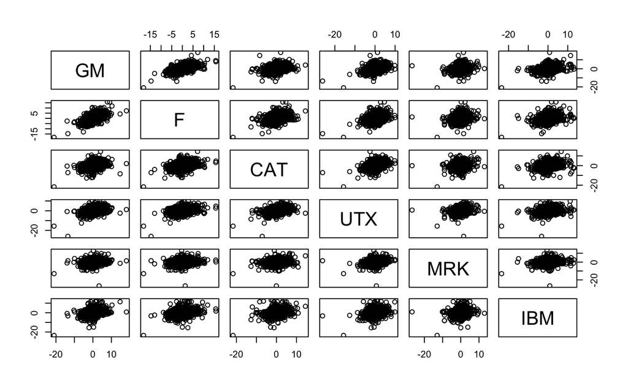

```r
dat = read.csv('Stock_Bond.csv', header = T)
prices = cbind(dat$GM_AC, dat$F_AC, dat$CAT_AC, dat$UTX_AC, dat$MRK_AC, dat$IBM_AC)
n = dim(prices)[1]
returns = 100* (prices[2:n,]/prices[1:(n-1),] - 1)
pairs(returns, labels = c('GM','F','CAT','UTX','MRK','IBM'))
```

```r
mean_vec = colMeans(returns)
cov_mat = cov(returns)
sd_vect = sqrt(diag(cov_mat))
```

```r
rf_daily = 3 / 365
Amat = matrix(cbind(rep(1,6), mean_vec, diag(6), -1 * diag(6)),6,14)
muP = seq(0.04, 0.08, length = 400)
# for the expect portforlio return
sdP = muP # set ip storage for std dev's pf portfolio returns
weights = matrix(0, nrow = 400, ncol = 6) # storage for weights
# find the optimal portforlios
for (i in 1:length(muP)){
  bvec = c(1, muP[i], rep(-0.1, 6), rep(-0.5, 6))
  result = solve.QP(Dmat = 2*cov_mat,
                    dvec = rep(0,6),
                    Amat = Amat,
                    bvec = bvec,
                    meq = 2)
  sdP[i] = sqrt(result$value)
  weights[i,] = result$solution
}
```

```r
# pdf("quad_orig_plot.pdf", width = 6, height = 5)
plot(sdP, muP, type = "l", xlim = c(0,2.5),
     ylim = c(0, 0.15), lty =3) # plot efficient frontier (and inefficient frontier below the min var portfortlio)
points(0, rf_daily, cex = 4, pch = "*") # show risk-free asset
```

```r
sharpe = (muP - rf_daily) / sdP # input value of risk-free interest asset
ind = (sharpe == max(sharpe))
cat("Sharpe ratio is: ", round(max(sharpe),3))
```

```
Sharpe ratio is:  0.048
```

```r
for (i in 1:6){
  cat("The weights of tangency portfolio of asset", i, ' is: ', weights[ind,i] * 100,'%\n')
}
```

```
The weights of tangency portfolio of asset 1  is:  -9.126047 %
The weights of tangency portfolio of asset 2  is:  -0.2938552 %
The weights of tangency portfolio of asset 3  is:  33.54128 %
The weights of tangency portfolio of asset 4  is:  38.37821 %
The weights of tangency portfolio of asset 5  is:  31.94956 %
The weights of tangency portfolio of asset 6  is:  5.55086 %
```

```r
lines(c(0,2), rf_daily + c(0,2) * (muP[ind] - rf_daily)/sdP[ind], lwd = 4, lty =1, col = "blue") # lines of optimal
                                      # portfolio
points(sdP[ind], muP[ind], cex = 3, pch = 1, col = "orange")
```

```r
ind2 = (sdP == min(sdP)) # find minimum variance portforlio
points(sdP[ind2], muP[ind2], cex = 2, pch = 24, col = "grey") # min var points
ind3 = (muP > muP[ind2])
# plot efficient frontier
lines(sdP[ind3], muP[ind3], type = "l", xlim = c(0, 0.25), ylim = c(0, 0.3), lwd = 3, col ='red')
```

```r
text(sd_vect[1], mean_vec[1], "GM", cex = 1)
text(sd_vect[2], mean_vec[2], "F", cex = 1)
```

```r
text(sd_vect[3], mean_vec[3], "CAT", cex = 1)
text(sd_vect[4], mean_vec[4], "UTX", cex = 1)
```

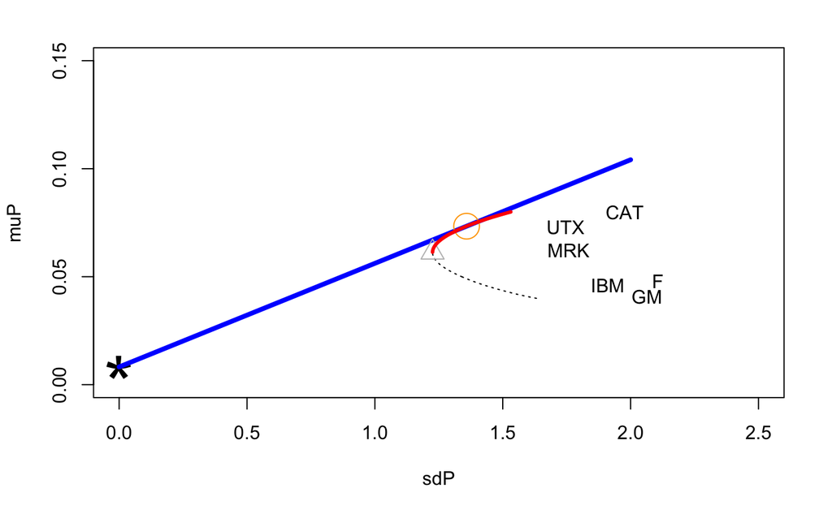

```r
text(sd_vect[5], mean_vec[5], "MRK", cex = 1)
text(sd_vect[6], mean_vec[6], "IBM", cex = 1)
```

## (b)

Problem 2 If an investor wants an efficient portfolio with an expected daily return of 0.07 %, how should the investor allocate his or her capital to the six stocks and to the risk-free asset? Assume that the investor wishes to use the tangency portfolio computed with the constraints −0.1 ≤ wj ≤ 0.5, not the unconstrained tangency portfolio.

```r
# mean return of mixed risky assets
mu_R = weights[ind,] %*% mean_vec
mu_t = 0.07
w = (mu_t - rf_daily) / (mu_R - rf_daily)
cat("Weight to risky assets is:",w,"\nWeight to risk-free asset is: ",1-w)
```

```
Weight to risky assets is: 0.948078
Weight to risk-free asset is:  0.05192198
```

```r
new_weights = weights[ind,] * as.vector(w)
cat("\n \n")
```

```r
for (i in 1:6){
  cat("The weights of risky asset", i, ' is: ', new_weights[i] * 100,'%\n')
}
```

```
The weights of risky asset 1  is:  -8.652205 %
The weights of risky asset 2  is:  -0.2785977 %
The weights of risky asset 3  is:  31.79975 %
The weights of risky asset 4  is:  36.38553 %
The weights of risky asset 5  is:  30.29067 %
The weights of risky asset 6  is:  5.262648 %
```

```r
cat("\nWeight to risk-free asset is: ",(1-w)*100,"%")
```

```
Weight to risk-free asset is:  5.192198 %
```

## (c):

```r
ideal_weights = weights[ind,]
R_m = ideal_weights %*% t(returns) #  vector of R_m
mu_m =mean(R_m)
var_m = var(matrix(R_m))
cov_m = cov(matrix(R_m), returns)
beta = cov_m / var_m[1]
print(beta)
```

```
          [,1]      [,2]     [,3]      [,4]      [,5]      [,6]
[1,] 0.5025742 0.6091944 1.099762 0.9917736 0.8318699 0.5832868
```

```r
test = (mean_vec - rf_daily)/(mu_m - rf_daily)
print(test)
```

```
[1] 0.5014730 0.6083292 1.0999827 0.9917554 0.8314977 0.5823643
```

```r
print("From the result, we can see that beta is very close to the SML line.")
```

```
[1] "From the result, we can see that beta is very close to the SML line."
```

# Q2

```r
cov_m = 0.0165
mu_f = 0.04
mu_m = 0.12
std_m = 0.11
beta = cov_m / (std_m ** 2)
cat("beta of Stock A: ", beta)
mu_R = beta * (mu_m - mu_f) + mu_f
cat("\n")
cat("expected return on Stock A: ", mu_R, '\n')
mkt_risk = (beta ** 2) * (std_m ** 2)
cat("market risk is: ", mkt_risk)
cat("precentage of market risk is: ", mkt_risk/0.025)
```

[output not shown]

```r
beta = 0.8* 0.3 + 0.9*0.3 + 0.7* 0.4
cat('new beta = ',beta,'\n')
```

```
new beta =  0.79
```

```r
var_m = 0.02
sa = 0.012
sb = 0.025
sc = 0.015
var_er = (beta ** 2) * var_m + (0.3 ** 2) * sa + (0.3 ** 2) * sb + (0.4 ** 2) * sc
cat('Variance of excess return is: ' ,var_er,'\n')
```

```
Variance of excess return is:  0.018212
```

```r
mkt_risk2 = (0.8) ^ 2 * var_er
non_mkt_risk = sa
prop = sqrt(mkt_risk2 / (mkt_risk2 + non_mkt_risk))
cat('Proportion of market risk is: ',prop * 100, '% \n')
```

```
Proportion of market risk is:  70.19418 %
```

# Q3

## (a)

$$E(X_n) = E(U \delta_n + \epsilon_n) = E(U) E(\delta_n) + E(\epsilon_n) = \frac{1}{2} + 0 = \frac{1}{2}$$
$$\sum(X_m,X_n) = cov(U\delta_n + \epsilon_n,U\delta_m + \epsilon_m)$$
By covariance summation we can rewrite into the sum of individual covarainces, and because
$$U,\delta,\epsilon$$
are independent to each other.
$$= cov(U,U) + cov(\epsilon_m,\epsilon_n)$$
$$= \frac{2}{3}, if m=n$$
$$= \frac{1}{12}, if m \neq n$$

## (b)

This contradicts with the ergodicity and autocorrelation shrink to zero with sufficient long lag. Therefore, X is non-ergodic.